# Final Project Summary Statistics

Codechella

Author

Annie Nadolski, Eleanor McElwee, Bryan Hwang, Henry Gresham

## 1 Load data

```r
bikes <- read.csv("../data/seoul_metro_bike_demand.csv", stringsAsFactors = TRUE)
```

## 2 Summary statistics

```r
bikes %>% glimpse()
```

```
Rows: 8,760
Columns: 14
$ Date                      <fct> 1/12/2017, 1/12/2017, 1/12/2017, 1…
$ Rented.Bike.Count         <int> 254, 204, 173, 107, 78, 100, 181, …
$ Hour                      <int> 0, 1, 2, 3, 4, 5, 6, 7, 8, 9, 10, …
$ Temperature..C.           <dbl> -5.2, -5.5, -6.0, -6.2, -6.0, -6.4…
$ Humidity...               <int> 37, 38, 39, 40, 36, 37, 35, 38, 37…
$ Wind.speed..m.s.          <dbl> 2.2, 0.8, 1.0, 0.9, 2.3, 1.5, 1.3,…
$ Visibility..10m.          <int> 2000, 2000, 2000, 2000, 2000, 2000…
$ Dew.point.temperature..C. <dbl> -17.6, -17.6, -17.7, -17.6, -18.6,…
$ Solar.Radiation..MJ.m2.   <dbl> 0.00, 0.00, 0.00, 0.00, 0.00, 0.00…
$ Rainfall.mm.              <dbl> 0, 0, 0, 0, 0, 0, 0, 0, 0, 0, 0, 0…
$ Snowfall..cm.             <dbl> 0, 0, 0, 0, 0, 0, 0, 0, 0, 0, 0, 0…
$ Seasons                   <fct> Winter, Winter, Winter, Winter, Wi…
$ Holiday                   <fct> No Holiday, No Holiday, No Holiday…
$ Functioning.Day           <fct> Yes, Yes, Yes, Yes, Yes, Yes, Yes,…
```

```r
bikes %>% summary()
```

```
        Date      Rented.Bike.Count      Hour       Temperature..C.
 1/1/2018 :  24   Min.   :   0.0    Min.   : 0.00   Min.   :-17.80
 1/10/2018:  24   1st Qu.: 191.0    1st Qu.: 5.75   1st Qu.:  3.50
 1/11/2018:  24   Median : 504.5    Median :11.50   Median : 13.70
 1/12/2017:  24   Mean   : 704.6    Mean   :11.50   Mean   : 12.88
 1/2/2018 :  24   3rd Qu.:1065.2    3rd Qu.:17.25   3rd Qu.: 22.50
 1/3/2018 :  24   Max.   :3556.0    Max.   :23.00   Max.   : 39.40
 (Other)  :8616
  Humidity...    Wind.speed..m.s. Visibility..10m.
 Min.   : 0.00   Min.   :0.000    Min.   :  27
 1st Qu.:42.00   1st Qu.:0.900    1st Qu.: 940
 Median :57.00   Median :1.500    Median :1698
 Mean   :58.23   Mean   :1.725    Mean   :1437
 3rd Qu.:74.00   3rd Qu.:2.300    3rd Qu.:2000
 Max.   :98.00   Max.   :7.400    Max.   :2000

 Dew.point.temperature..C. Solar.Radiation..MJ.m2.  Rainfall.mm.
 Min.   :-30.600           Min.   :0.0000          Min.   : 0.0000
 1st Qu.: -4.700           1st Qu.:0.0000          1st Qu.: 0.0000
 Median :  5.100           Median :0.0100          Median : 0.0000
 Mean   :  4.074           Mean   :0.5691          Mean   : 0.1487
 3rd Qu.: 14.800           3rd Qu.:0.9300          3rd Qu.: 0.0000
 Max.   : 27.200           Max.   :3.5200          Max.   :35.0000

 Snowfall..cm.       Seasons           Holiday     Functioning.Day
 Min.   :0.00000   Autumn:2184   Holiday   : 432   No : 295
 1st Qu.:0.00000   Spring:2208   No Holiday:8328   Yes:8465
 Median :0.00000   Summer:2208
 Mean   :0.07507   Winter:2160
 3rd Qu.:0.00000
 Max.   :8.80000
```

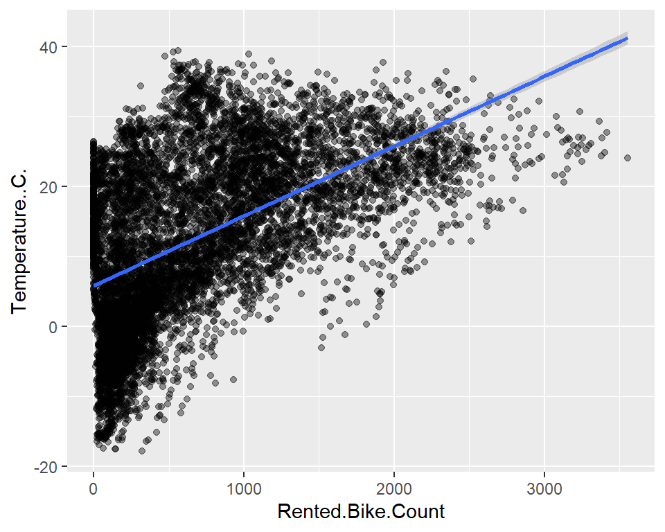

```r
ggplot(data = bikes, aes(x = Rented.Bike.Count, y = Temperature..C.)) +
  geom_point(alpha = 0.4) +
  geom_smooth(method = "lm")
```

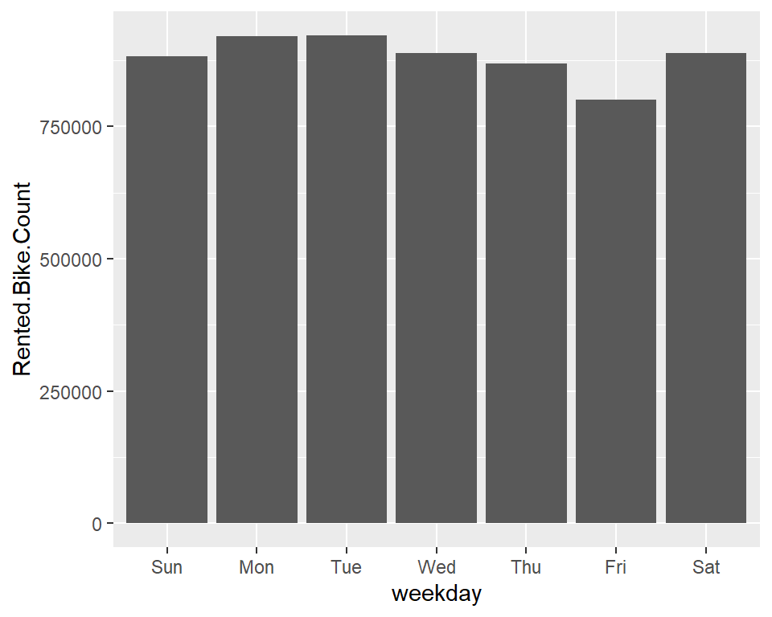

```r
# use lubridate package to look at the dates for seasonality (wday(), year(), month(), etc.)
# can use lagged term for a predictor (number of bikes used in each of the previous 12 days in the same hour or number of bikes used at this time last year)

bikes <- bikes %>%
  mutate(
    weekday      = wday(Date, label = TRUE),
    month_name   = month(Date, label = TRUE),
    is_weekend   = factor(ifelse(wday(Date) %in% c(1, 7), 1, 0))
  )


ggplot(bikes, aes(x = weekday, y = Rented.Bike.Count)) +
  geom_bar(stat = "identity")
```

```r
bikes %>% group_by(weekday) %>%
  summarise(avg_bike_count = mean(Rented.Bike.Count))
```

| weekday | avg_bike_count |
| --- | --- |
| Sun | 706.9327 |
| Mon | 737.6587 |
| Tue | 738.4752 |
| Wed | 712.1899 |
| Thu | 696.9944 |
| Fri | 641.4728 |
| Sat | 698.6061 |

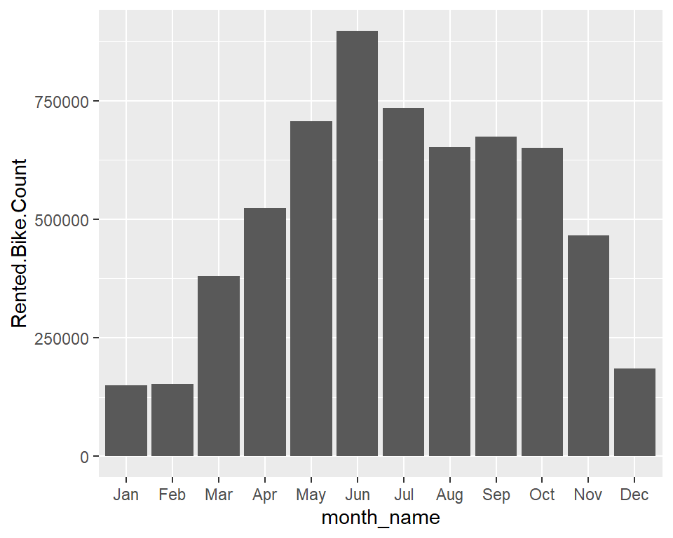

```r
ggplot(bikes, aes(x = month_name, y = Rented.Bike.Count)) +
  geom_bar(stat = "identity")
```

## 3 Feature Engineering Plan

What we are planning to do: Categorize variables such as humidity, wind speed, and visibility into subgroups such as high humidity, mid humidity, and low humidity

Split up the hours of the day into categories like commuting hours and night time

What we have done (might still need to do more): Change the date variable into something meaningful, extract weekdays, months, is weekend

Check for high correlation between the variables, for example we have months and seasons, but we only need one.

## 4 Linear Regression

```r
bikes_clean <- bikes %>%
  select(-Date, -Seasons, -is_weekend) %>%
  drop_na()

model1 <- lm(Rented.Bike.Count ~ ., data = bikes_clean)

summary(model1)
```

```
Call:
lm(formula = Rented.Bike.Count ~ ., data = bikes_clean)

Residuals:
     Min       1Q   Median       3Q      Max
-1326.45  -263.20   -46.93   207.38  1980.44

Coefficients:
                            Estimate Std. Error t value
(Intercept)               -437.31953   95.78087  -4.566
Hour                        26.76709    0.71323  37.529
Temperature..C.             19.71391    3.56254   5.534
Humidity...                -10.15213    0.99294 -10.224
Wind.speed..m.s.            23.29232    4.90106   4.753
Visibility..10m.             0.06610    0.01103   5.990
Dew.point.temperature..C.   12.21960    3.73653   3.270
Solar.Radiation..MJ.m2.    -89.38073    7.31896 -12.212
Rainfall.mm.               -57.81853    4.09686 -14.113
Snowfall..cm.               31.61105   10.85566   2.912
HolidayNo Holiday          133.62830   21.04038   6.351
Functioning.DayYes         948.31649   25.72497  36.864
weekday.L                  -34.20326   11.78316  -2.903
weekday.Q                  -22.50268   11.80209  -1.907
weekday.C                    3.95744   11.78343   0.336
weekday^4                   -7.62897   11.77044  -0.648
weekday^5                    4.19944   11.76779   0.357
weekday^6                    2.42137   11.73347   0.206
month_name.L               173.43059   20.33218   8.530
month_name.Q              -121.16270   45.44257  -2.666
month_name.C                76.33735   19.49981   3.915
month_name^4              -129.19126   17.19869  -7.512
month_name^5              -392.12156   16.41210 -23.892
month_name^6               -13.91655   15.66685  -0.888
month_name^7               252.61554   16.43273  15.373
month_name^8               140.42792   15.40809   9.114
month_name^9              -165.29390   15.47169 -10.684
month_name^10             -109.48650   15.46000  -7.082
month_name^11               41.58641   15.38150   2.704
                                      Pr(>|t|)
(Intercept)                 0.0000050432352793 ***
```

[output cut: 19 more lines]

```
month_name.C                0.0000911771505665 ***
month_name^4                0.0000000000000641 ***
month_name^5              < 0.0000000000000002 ***
month_name^6                           0.37441
month_name^7              < 0.0000000000000002 ***
month_name^8              < 0.0000000000000002 ***
month_name^9              < 0.0000000000000002 ***
month_name^10               0.0000000000015318 ***
month_name^11                          0.00687 **
---
Signif. codes:  0 '***' 0.001 '**' 0.01 '*' 0.05 '.' 0.1 ' ' 1

Residual standard error: 413.4 on 8731 degrees of freedom
Multiple R-squared:  0.5905,    Adjusted R-squared:  0.5892
F-statistic: 449.6 on 28 and 8731 DF,  p-value: < 0.00000000000000022
```

## 5 Road blocks and open questions

Github is currently a roadblock. We need to figure out how to make sure we can all access the data file and know how to collaborate on github.

There is currently a Korean character in our data file and 3/4 of us have issues reading the file.

We also want to figure out how to make our bar chart of weekday and count weekday and average count.

We still need to run our ridge regression.

How do we split the data by time instead of randomly?